```python
import pandas as pd
import numpy as np
import matplotlib.pyplot as plt
import seaborn as sns
from sklearn.model_selection import TimeSeriesSplit, GridSearchCV
from sklearn.ensemble import RandomForestRegressor
from sklearn.metrics import mean_squared_error
```

# Team 4

## Real Estate Score Card

The data we are analyzing is related to real estate prices from Zillow. The data is in the form of a CSV file, containing the following columns:

- **RegionID**: Unique identifier for the region
- **SizeRank**: Rank of the region based on size
- **RegionName**: Name of the region
- **RegionType**: Type of the region: neighborhood
- **StateName**: Name of the state
- **State**: Abbreviation of the state
- **City**
- **Metro**
- **CountyName**
- **Series of Dates from 2000-01 to 2024-09**, incremented per month

The values associated we are looking at is called the Zillow Home Value Index (ZHVI).

**Zillow Home Value Index (ZHVI)**: A measure of the typical home value and market changes across a given region and housing type. It reflects the typical value for homes in the 35th to 65th percentile range. More info about ZHVI: [Zillow Research](https://www.zillow.com/research/methodology-neural-zhvi-32128/)

Our analysis will be focused on the Chicago land area consisting of all its neighborhoods and regions associated.

```python
# Read in the file
df = pd.read_csv('Neighborhood_zillow.csv')
Neighborhoods_zillow_df = df.copy()
print("shape:", df.shape)
```

```
shape: (21628, 306)
```

```python
# Clean the data to only include chicago neighborhoods
chicago_df = df[df['City'] == 'Chicago']

# List the neighborhoods

print("Number of unique region names in Chicago:", df['RegionName'].unique().size)

# Remove the columns that are not needed
chicago_df = chicago_df.drop(columns=['StateName', 'Metro', 'CountyName'])

# Save the df into a csv for chicago
chicago_df.to_csv('Chicago_Neighborhoods.csv', index=False)
```

[output not shown]

```python
# Filter regions into unique dataframes

# North Side
north_side_regions = [
    'Rogers Park', 'Edgewater', 'Uptown', 'Lake View', 'Lincoln Park',
    'North Center', 'Lincoln Square', 'West Ridge', 'Irving Park',
    'Albany Park', 'Avondale'
]
north_side_df = chicago_df[chicago_df['RegionName'].isin(north_side_regions)]

# South Side
south_side_regions = [
    'Armour Square', 'Bridgeport', 'Brighton Park', 'New City (Back of the Yards)',
    'Englewood', 'Greater Grand Crossing', 'Hyde Park', 'Kenwood', 'Oakland',
    'South Shore', 'Washington Park', 'Woodlawn', 'Chatham', 'South Chicago',
    'Auburn Gresham', 'Calumet Heights', 'Roseland', 'Pullman', 'West Pullman',
    'Riverdale'
]
south_side_df = chicago_df[chicago_df['RegionName'].isin(south_side_regions)]

# East Side
east_side_regions = [
    'Hegewisch', 'East Side', 'South Shore', 'Hyde Park', 'Kenwood'

]
east_side_df = chicago_df[chicago_df['RegionName'].isin(east_side_regions)]

# West Side
west_side_regions = [
    'Austin', 'East Garfield Park', 'West Garfield Park', 'North Lawndale',
    'South Lawndale (Little Village)', 'Humboldt Park', 'Near West Side', 'West Town'
]
west_side_df = chicago_df[chicago_df['RegionName'].isin(west_side_regions)]

# Northwest Side
northwest_side_regions = [
    'Jefferson Park', 'Portage Park', 'Norwood Park', 'Dunning', 'Belmont Cragin',
    'Montclare', 'Irving Park', 'Hermosa'
]
northwest_side_df = chicago_df[chicago_df['RegionName'].isin(northwest_side_regions)]

# Southwest Side
southwest_side_regions = [
    'Garfield Ridge', 'Archer Heights', 'Brighton Park', 'Gage Park', 'West Elsdon',
    'West Lawn', 'Chicago Lawn (Marquette Park)', 'Ashburn', 'Clearing'
]
southwest_side_df = chicago_df[chicago_df['RegionName'].isin(southwest_side_regions)]

print("North Side neighborhoods: \n", north_side_df.head(3))
# print("South Side neighborhoods: \n", south_side_df.head(8))
# print("East Side neighborhoods: \n", east_side_df.head(8))
# print("West Side neighborhoods: \n", west_side_df.head(8))
# print("Northwest Side neighborhoods: \n", northwest_side_df.head(8))
# print("Southwest Side neighborhoods: \n", southwest_side_df.head(8))

# print("North Side neighborhoods: \n", north_side_df.head())
# print("South Side neighborhoods: \n", south_side_df.head())
# print("East Side neighborhoods: \n", east_side_df.head())
# print("West Side neighborhoods: \n", west_side_df.head())
# print("Northwest Side neighborhoods: \n", northwest_side_df.head())
# print("Southwest Side neighborhoods: \n", southwest_side_df.head())
```

```
North Side neighborhoods:
    RegionID  SizeRank    RegionName    RegionType State     City  \
0    269589        42     Lake View  neighborhood    IL  Chicago
1    403169        88    West Ridge  neighborhood    IL  Chicago
4    269590       124  Lincoln Park  neighborhood    IL  Chicago

      2000-01-31     2000-02-29     2000-03-31     2000-04-30  ...  \
0  208551.012512  209149.320482  210198.354707  212368.224292  ...
1   96139.758695   96213.550642   96575.422669   97341.595605  ...
4  357432.681307  357953.646643  359178.749081  361895.608303  ...

      2023-12-31     2024-01-31     2024-02-29     2024-03-31     2024-04-30  \
0  362821.310242  362271.074605  361924.480636  363486.194643  366055.463566
1  245181.629200  245168.670844  245722.574626  247565.523551  250479.623557
4  538063.265535  537392.813508  536968.038013  539150.260774  542337.411739

      2024-05-31     2024-06-30     2024-07-31     2024-08-31     2024-09-30
0  368809.172277  370385.712297  371789.721511  372978.814528  373726.663850
1  252322.432731  252784.184379  252908.471644  252929.148211  252490.590203
4  545817.433945  547945.379384  550400.634121  552423.640232  554166.819059

[3 rows x 303 columns]
```

```python
# Unpivot date columns so data is more rectangular
def reshape_dates(df):
    # Identify date columns
    date_columns = [col for col in df.columns if col.startswith('20')]

    # Melt dataframe to convert date columns into rows
    df_melted = df.melt(id_vars=['RegionID', 'SizeRank', 'RegionName'],
                        value_vars=date_columns,
                        var_name='Date', value_name='ZHVI')

    # Convert Date to datetime fromat
    df_melted['Date'] = pd.to_datetime(df_melted['Date'])

    return df_melted

reshaped_df = reshape_dates(chicago_df)
reshaped_df.head()
```

|  | RegionID | SizeRank | RegionName | Date | ZHVI |
| --- | --- | --- | --- | --- | --- |
| 0 | 269589 | 42 | Lake View | 2000-01-31 | 208551.012512 |
| 1 | 403169 | 88 | West Ridge | 2000-01-31 | 96139.758695 |
| 2 | 403117 | 97 | Little Village | 2000-01-31 | 93685.837781 |
| 3 | 269592 | 99 | Logan Square | 2000-01-31 | 163429.707813 |
| 4 | 269590 | 124 | Lincoln Park | 2000-01-31 | 357432.681307 |

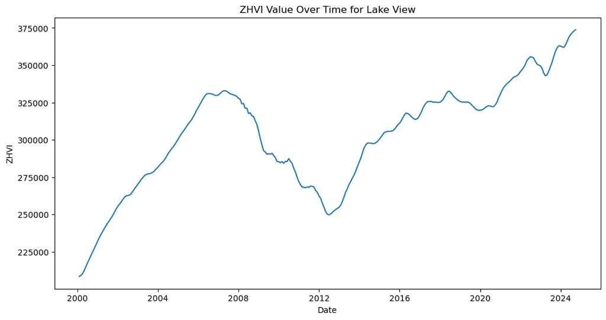

```python
# Filter for Lake View
lake_view_df = reshaped_df[reshaped_df['RegionName'] == 'Lake View']

# Plot ZHVI over time for Lake View
plt.figure(figsize=(12, 6))
sns.lineplot(x='Date', y='ZHVI', data=lake_view_df)
plt.title("ZHVI Value Over Time for Lake View")
plt.xlabel("Date")
plt.ylabel("ZHVI")
plt.show()
```

```python
cens = pd.read_csv('Data/Census-2020.csv')
cens['Label (Grouping)'].to_list
```

```
<bound method IndexOpsMixin.tolist of 0                                       Total population
1                                            SEX AND AGE
2                                                   Male
3                                                 Female
4                                          Under 5 years
                             ...
154                                   30 percent or more
155                        Renter-occupied housing units
156        GROSS RENT AS A PERCENTAGE OF HOUSEHOLD IN...
157                                 Less than 30 percent
158                                   30 percent or more
Name: Label (Grouping), Length: 159, dtype: object>
```

```python
def clean_census(year):
    filename = 'Data/Census-' + str(year) + '.csv'
    raw_df = pd.read_csv(filename)

    # Filter only Total Estimate columns
    columns = raw_df.columns.str
    df = raw_df.loc[:, columns.contains('Total!!Estimate')]
    df.loc[:,'Label'] = raw_df['Label (Grouping)']

    # Transpose columns and rows
    df = df.set_index('Label').transpose().reset_index()

    # Rename columns that have Year in the name
    df = df.rename(columns={'index': 'ZIP Code',
                            'INCOME IN THE PAST 12 MONTHS (IN ' + str(year) + ' INFLATION-ADJUSTED DOLLARS)':
                            'INCOME IN THE PAST 12 MONTHS (IN INFLATION-ADJUSTED DOLLARS)',
                            'EARNINGS IN THE PAST 12 MONTHS (IN ' + str(year) + ' INFLATION-ADJUSTED DOLLARS) FOR FULL-TIME, YEAR-ROUND WORKERS':
                            'EARNINGS IN THE PAST 12 MONTHS (IN INFLATION-ADJUSTED DOLLARS) FOR FULL-TIME, YEAR-ROUND WORKERS'})


    # Rename columns so each is unique
    new_columns = []
    prefix = ''

    for col in df.columns:
        col = col.replace('\xa0', '')
        if col.isupper():
            # If the column name is all uppercase, set it as the prefix
            prefix = col
            new_columns.append(col)
        else:
            # Add the prefix to the column name
            new_columns.append(f"{prefix} - {col}")

    df.columns = new_columns
    df.columns = df.columns.str.strip()

    # Remove columns with all NaN values
    df = df.dropna(axis=1, how='all')

    # This column was causing trouble so remove it
    for col in df.columns:
        if 'with related children' in col.lower():
            df.drop(columns=[col])

    df = df.rename(columns={'- ZIP Code': 'ZIP Code', '- Total population': 'Total population'})
    df['ZIP Code'] = df['ZIP Code'].str[6:11]

    for col in df.columns:
        try:
            # Check if the column is of type 'object'
            if df[col].dtype == 'object':

                # Remove commas
                df[col] = df[col].replace({',': ''}, regex=True)

                # Check if the column contains percentages
                if df[col].str.contains('%').any():
                    # Convert to float after removing % sign and divide by 100
                    df[col] = df[col].str.rstrip('%').astype('float') / 100
                else:
                    df[col] = pd.to_numeric(df[col])

        except Exception as e:
            nonee = ''

    # Clean up column names and add year column
    df['Year'] = year

    return df


census_df = clean_census(2011)

# Loop through each year and add it to the census_df
for year in range(2012,2023):
    df = clean_census(year)

    # Remove columns not in the intersection so they can be concated
    common_columns = census_df.columns.intersection(df.columns)
    census_df = census_df[common_columns]
    df = df[common_columns]

    census_df = pd.concat([census_df, df], ignore_index=True)

census_df['ZIP Code'] = census_df['ZIP Code'].astype(str)

# Set display options to show all rows and columns
# pd.set_option('display.max_rows', None)
# pd.set_option('display.max_columns', None)
census_df
```

[output not shown]

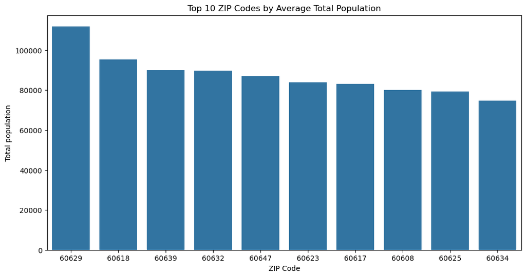

```python
# print(census_df.dtypes)
# Group by Zip and get average of population
grouped_df = census_df.groupby('ZIP Code')['Total population'].mean().reset_index()

# Get the top 10 ZIP codes by average population
top_10 = grouped_df.sort_values('Total population', ascending=False).head(10)

plt.figure(figsize=(12, 6))
sns.barplot(x='ZIP Code', y='Total population', data=top_10)
plt.title('Top 10 ZIP Codes by Average Total Population')
plt.show()
```

```python
# Clean up populations csv's
def clean_population(year):
    filename = 'Chicago_ZIP_Populations_' + str(year) + '.csv'
    df = pd.read_csv(filename)

    # Transpose columns and rows
    df = df.set_index('Label (Grouping)').transpose().reset_index()

    # Rename columns
    df.columns = ['Zip Code', 'Total']

    # Remove prefix from Zip codes
    df['Zip Code'] = df['Zip Code'].str[6:]
    df['Year'] = year

    return df

pop_2010 = clean_population(2010)
pop_2020 = clean_population(2020)

# Combine both years into one dataframe
population_df = pd.concat([pop_2010, pop_2020], ignore_index=True)

population_df
```

|  | Zip Code | Total | Year |
| --- | --- | --- | --- |
| 0 | 60601 | 11,110 | 2010 |
| 1 | 60602 | 1,204 | 2010 |
| 2 | 60603 | 493 | 2010 |
| 3 | 60604 | 570 | 2010 |
| 4 | 60605 | 24,668 | 2010 |
| ... | ... | ... | ... |
| 107 | 60656 | 28,474 | 2020 |
| 108 | 60657 | 72,316 | 2020 |
| 109 | 60659 | 40,579 | 2020 |
| 110 | 60660 | 42,534 | 2020 |
| 111 | 60661 | 11,987 | 2020 |

112 rows × 3 columns

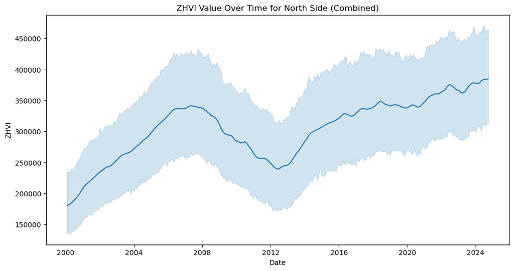

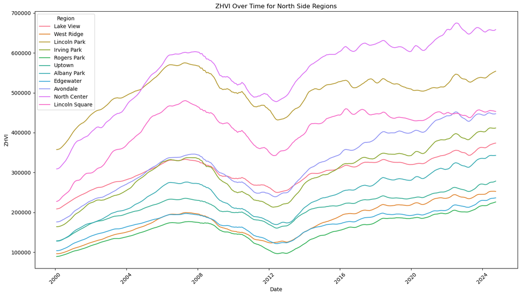

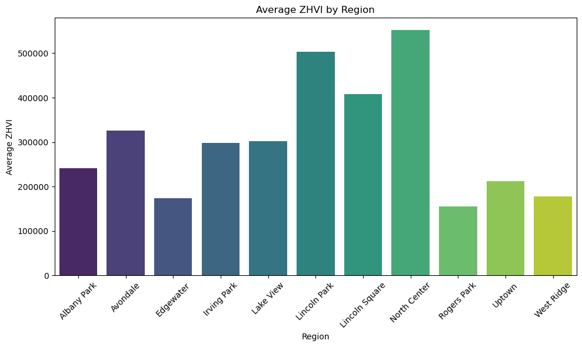

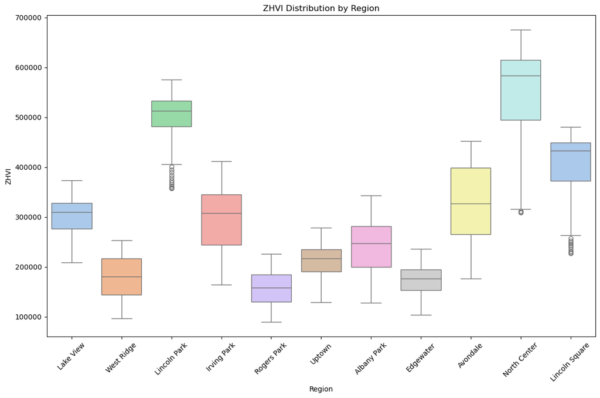

```python
# north side

reshaped_north_side_df = reshape_dates(north_side_df)

# print ("North Side neighborhoods: \n", reshaped_north_side_df["RegionName"].unique())
# print ("North Side neighborhoods: \n", reshaped_north_side_df.columns)

# Ensure Date column is in datetime format
reshaped_north_side_df['Date'] = pd.to_datetime(reshaped_north_side_df['Date'])

# Plot ZHVI over time for Lake View
plt.figure(figsize=(12, 6))
sns.lineplot(x='Date', y='ZHVI', data=reshaped_north_side_df)
plt.title("ZHVI Value Over Time for North Side (Combined)")
plt.xlabel("Date")
plt.ylabel("ZHVI")
plt.show()

# 1. ZHVI Over Time for North Side - Line Graph
plt.figure(figsize=(14, 8))
sns.lineplot(data=reshaped_north_side_df, x='Date', y='ZHVI', hue='RegionName')
plt.title('ZHVI Over Time for North Side Regions')
plt.xlabel('Date')
plt.ylabel('ZHVI')
plt.legend(title='Region')
plt.xticks(rotation=45)
plt.tight_layout()
plt.show()

# 2. Average ZHVI by Region - Bar Chart
average_zhvi_by_region = reshaped_north_side_df.groupby('RegionName')['ZHVI'].mean().reset_index()

plt.figure(figsize=(10, 6))
sns.barplot(data=average_zhvi_by_region, x='RegionName', y='ZHVI', palette='viridis')
plt.title('Average ZHVI by Region')
plt.xlabel('Region')
plt.ylabel('Average ZHVI')
plt.xticks(rotation=45)
plt.tight_layout()
plt.show()

# 3. ZHVI Distribution by Region - Box Plot
plt.figure(figsize=(12, 8))
sns.boxplot(data=reshaped_north_side_df, x='RegionName', y='ZHVI', palette='pastel')
plt.title('ZHVI Distribution by Region')
plt.xlabel('Region')
plt.ylabel('ZHVI')
plt.xticks(rotation=45)
plt.tight_layout()
plt.show()
```

ZHVI Value Over Time for North Side (Combined) - This visualization provides a broad view of the overall Zillow Home Value Index (ZHVI) trends across all neighborhoods in the North Side, giving a quick overview of how property values have evolved in this region as a whole.

ZHVI Over Time for North Side Regions - By breaking down ZHVI trends for individual neighborhoods within the North Side, this graph allows for a more detailed comparison, helping identify which neighborhoods have higher growth rates or stability over time.

Average ZHVI by Region - Bar Chart - This bar chart highlights the average ZHVI across North Side neighborhoods, offering a clear comparison of property values among neighborhoods, which is useful for assessing relative affordability and investment potential.

ZHVI Distribution by Region - Box Plot - The box plot shows the range and variability of ZHVI within each neighborhood, illustrating price distribution and identifying areas with higher volatility or consistency in home values, which can indicate market stability.

```python
Neighborhoods_zillow_df = Neighborhoods_zillow_df[Neighborhoods_zillow_df['City'] == "Chicago"]
Neighborhoods_zillow_df.to_csv('Chicago_Neighborhoods_Zillow.csv', index=False)
```

```
Best parameters: {'max_depth': 200, 'min_samples_split': 2, 'n_estimators': 1000}
RMSE: 598.2984169567807
```

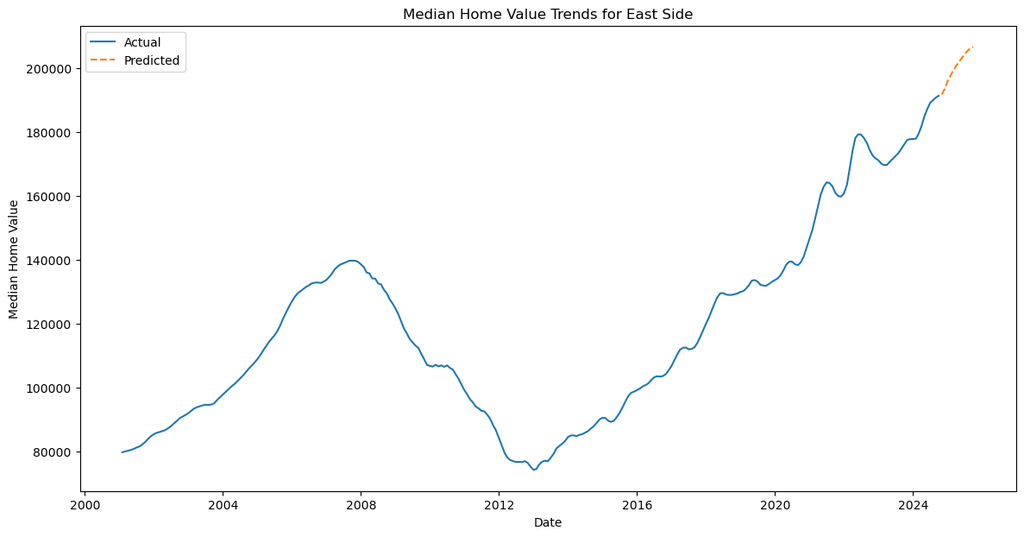

```python
# 1. Load the dataset
df = pd.read_csv('Chicago_Neighborhoods_Zillow.csv')

# 2. Define the East Side regions
east_side_regions = [
    'Hegewisch', 'East Side', 'South Shore', 'Hyde Park', 'Kenwood'
]

# 3. Filter the DataFrame to include only the East Side regions
df = df[df['RegionName'].isin(east_side_regions)]

# 4. Reshape the data from wide to long format
# Identify non-date columns
non_date_cols = ['RegionID', 'SizeRank', 'RegionName', 'RegionType', 'StateName',
                 'State', 'City', 'Metro', 'CountyName']

# Reshape the DataFrame
df_long = df.melt(id_vars=non_date_cols, var_name='Date', value_name='MedianHomeValue')

# Convert 'Date' to datetime format
df_long['Date'] = pd.to_datetime(df_long['Date'])

# 5. Handle missing values
df_long.dropna(subset=['MedianHomeValue'], inplace=True)

# 6. Feature engineering
# Extract 'Year' and 'Month' from 'Date'
df_long['Year'] = df_long['Date'].dt.year
df_long['Month'] = df_long['Date'].dt.month

# 7. Create lag features
# Sort values
df_long.sort_values(['RegionName', 'Date'], inplace=True)

# Create lag features for the past 12 months
for lag in range(1, 13):
    df_long[f'Lag_{lag}'] = df_long.groupby('RegionName')['MedianHomeValue'].shift(lag)

# Drop rows with NaN values due to lagging
df_long.dropna(inplace=True)

# 8. Encode categorical variables
# One-hot encode 'RegionType' if necessary
df_encoded = pd.get_dummies(df_long, columns=['RegionType'], drop_first=True)

# 9. Define features and target variable
# Lag features
lag_features = [f'Lag_{lag}' for lag in range(1, 13)]
# Categorical features (if any)
categorical_features = [col for col in df_encoded.columns if col.startswith('RegionType_')]
# All features
features = lag_features + ['Year', 'Month'] + categorical_features

X = df_encoded[features]
y = df_encoded['MedianHomeValue']

# 10. Split the data using TimeSeriesSplit
tscv = TimeSeriesSplit(n_splits=3)

# 11. Model training and selection
# Initialize the model
rf = RandomForestRegressor(random_state=42)

# Simplify hyperparameter tuning for quicker runtime
param_grid = {
    'n_estimators': [1000],
    'max_depth': [200],
    'min_samples_split': [2]
}

grid_search = GridSearchCV(estimator=rf, param_grid=param_grid, cv=tscv,
                           scoring='neg_mean_squared_error', n_jobs=-1)
grid_search.fit(X, y)

# Best estimator
best_model = grid_search.best_estimator_
print(f'Best parameters: {grid_search.best_params_}')

# 12. Evaluate the model
# Predictions on the training set
y_pred = best_model.predict(X)

# Calculate RMSE
rmse = np.sqrt(mean_squared_error(y, y_pred))
print(f'RMSE: {rmse}')

# 13. Forecast future values
# Predict the next 12 months
future_dates = pd.date_range(start=df_long['Date'].max() + pd.DateOffset(months=1),
                             periods=12, freq='ME')  #change periods to 24 for 2 years

# Create a DataFrame for future predictions
future_df = pd.DataFrame({'Date': future_dates})

# Prepare future predictions for each region
regions = df_long['RegionName'].unique()
future_predictions_list = []  # Use a list to collect DataFrames

for region in regions:
    # Get the last known data for the region
    region_data = df_encoded[df_encoded['RegionName'] == region].sort_values('Date')
    last_row = region_data.iloc[-1]

    # Initialize lag values
    lag_values = last_row[[f'Lag_{lag}' for lag in range(1, 13)]].values
    # The most recent value is 'MedianHomeValue' from the last row
    last_value = last_row['MedianHomeValue']

    # Create future data for the region
    temp_df = future_df.copy()
    temp_df['RegionName'] = region
    temp_df['Year'] = temp_df['Date'].dt.year
    temp_df['Month'] = temp_df['Date'].dt.month

    # Include any encoded 'RegionType' columns
    for col in categorical_features:
        temp_df[col] = last_row[col]

    # Initialize a DataFrame to store lag features
    predicted_values = []

    for i in range(len(temp_df)):
        # Create a dictionary to hold features for this date
        features_dict = {}
        # Set lag features
        for lag in range(1, 13):
            features_dict[f'Lag_{lag}'] = lag_values[lag-1]
        # Combine features
        features_input = pd.DataFrame(features_dict, index=[0])
        features_input['Year'] = temp_df.iloc[i]['Year']
        features_input['Month'] = temp_df.iloc[i]['Month']
        for col in categorical_features:
            features_input[col] = temp_df.iloc[i][col]
        # Ensure all features are present
        features_input = features_input[features]
        # Predict the median home value
        predicted_value = best_model.predict(features_input)[0]
        predicted_values.append(predicted_value)
        # Update lag values
        lag_values = np.roll(lag_values, 1)
        lag_values[0] = predicted_value  # The most recent lag is the predicted value

    # Add the predicted values to temp_df
    temp_df['PredictedMedianHomeValue'] = predicted_values

    # Collect temp_df in the list
    future_predictions_list.append(temp_df[['Date', 'RegionName', 'PredictedMedianHomeValue']])

# Concatenate all future predictions into a single DataFrame
future_predictions = pd.concat(future_predictions_list, ignore_index=True)

# 14. Visualize the predictions
# Select a region to visualize (e.g., 'East Side')
region_to_plot = 'East Side'  # Replace with an actual region name from your data

# Actual data
actual_data = df_long[df_long['RegionName'] == region_to_plot]

# Predicted data
predicted_data = future_predictions[future_predictions['RegionName'] == region_to_plot]

# Plotting
plt.figure(figsize=(14, 7))
plt.plot(actual_data['Date'], actual_data['MedianHomeValue'], label='Actual')
plt.plot(predicted_data['Date'], predicted_data['PredictedMedianHomeValue'],
         label='Predicted', linestyle='--')
plt.title(f'Median Home Value Trends for {region_to_plot}')
plt.xlabel('Date')
plt.ylabel('Median Home Value')
plt.legend()
plt.show()
```

This visualization is beneficial as it focuses on the East Side regions, allowing for a detailed view of historical and predicted home value trends in a specific area, which is useful for regional market analysis and targeted investment decisions.

```
Best parameters: {'max_depth': 200, 'min_samples_split': 2, 'n_estimators': 1000}
RMSE: 686.3774674333271
```

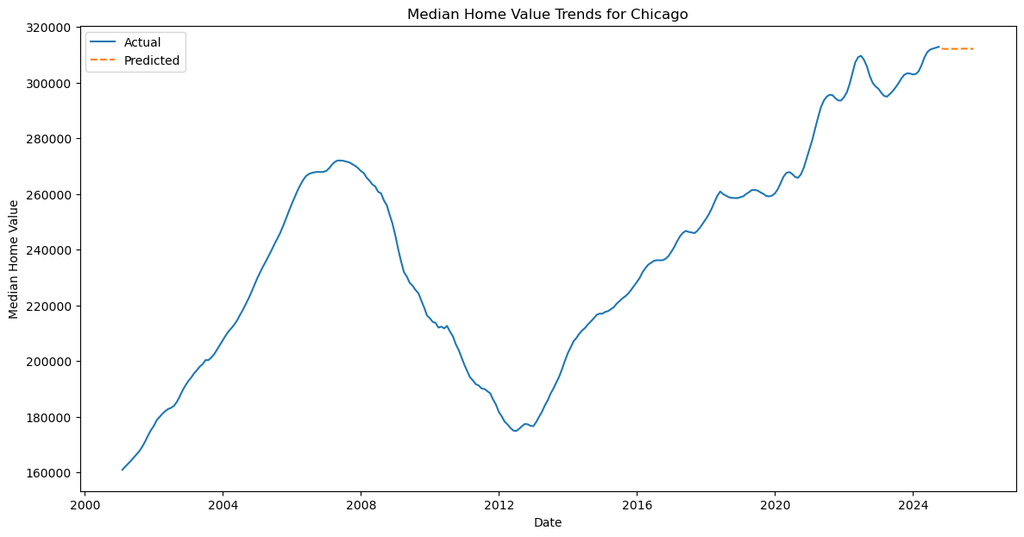

```python
# 1. Load the dataset
df = pd.read_csv('Chicago_Neighborhoods_Zillow.csv')

# 2. Reshape the data from wide to long format
# Identify non-date columns
non_date_cols = ['RegionID', 'SizeRank', 'RegionName', 'RegionType', 'StateName',
                 'State', 'City', 'Metro', 'CountyName']

# Reshape the DataFrame
df_long = df.melt(id_vars=non_date_cols, var_name='Date', value_name='MedianHomeValue')

# Convert 'Date' to datetime format
df_long['Date'] = pd.to_datetime(df_long['Date'])

# 3. Handle missing values
df_long.dropna(subset=['MedianHomeValue'], inplace=True)

# 4. Aggregate the data across all regions
# Calculate the average median home value for each date
aggregate_data = df_long.groupby('Date')['MedianHomeValue'].mean().reset_index()

# 5. Feature engineering
# Extract 'Year' and 'Month' from 'Date'
aggregate_data['Year'] = aggregate_data['Date'].dt.year
aggregate_data['Month'] = aggregate_data['Date'].dt.month

# 6. Create lag features
# Sort values
aggregate_data.sort_values('Date', inplace=True)

# Create lag features for the past 12 months
for lag in range(1, 13):
    aggregate_data[f'Lag_{lag}'] = aggregate_data['MedianHomeValue'].shift(lag)

# Drop rows with NaN values due to lagging
aggregate_data.dropna(inplace=True)

# 7. Define features and target variable
# Lag features
lag_features = [f'Lag_{lag}' for lag in range(1, 13)]
# All features
features = lag_features + ['Year', 'Month']

X = aggregate_data[features]
y = aggregate_data['MedianHomeValue']

# 8. Split the data using TimeSeriesSplit
tscv = TimeSeriesSplit(n_splits=3)

# 9. Model training and selection
# Initialize the model
rf = RandomForestRegressor(random_state=42)

# Adjust hyperparameters as needed
param_grid = {
    'n_estimators': [1000],  # Adjust based on your system's capacity
    'max_depth': [200],
    'min_samples_split': [2]
}

grid_search = GridSearchCV(estimator=rf, param_grid=param_grid, cv=tscv,
                           scoring='neg_mean_squared_error', n_jobs=-1)
grid_search.fit(X, y)

# Best estimator
best_model = grid_search.best_estimator_
print(f'Best parameters: {grid_search.best_params_}')

# 10. Evaluate the model
# Predictions on the training set
y_pred = best_model.predict(X)

# Calculate RMSE
rmse = np.sqrt(mean_squared_error(y, y_pred))
print(f'RMSE: {rmse}')

# 11. Forecast future values
# Predict the next 12 months
future_dates = pd.date_range(start=aggregate_data['Date'].max() + pd.DateOffset(months=1),
                             periods=12, freq='ME')  # Change periods to 24 for 2 years if needed

# Create a DataFrame for future predictions
future_df = pd.DataFrame({'Date': future_dates})
future_df['Year'] = future_df['Date'].dt.year
future_df['Month'] = future_df['Date'].dt.month

# Initialize lag values with the last available data
lag_values = aggregate_data.iloc[-1][lag_features].values

predicted_values = []

for i in range(len(future_df)):
    # Create a dictionary to hold features for this date
    features_dict = {}
    # Set lag features
    for lag in range(1, 13):
        features_dict[f'Lag_{lag}'] = lag_values[lag-1]
    # Combine features
    features_input = pd.DataFrame(features_dict, index=[0])
    features_input['Year'] = future_df.iloc[i]['Year']
    features_input['Month'] = future_df.iloc[i]['Month']
    features_input = features_input[features]
    # Predict the median home value
    predicted_value = best_model.predict(features_input)[0]
    predicted_values.append(predicted_value)
    # Update lag values
    lag_values = np.roll(lag_values, 1)
    lag_values[0] = predicted_value  # The most recent lag is the predicted value

# Add the predicted values to future_df
future_df['PredictedMedianHomeValue'] = predicted_values

# 12. Visualize the predictions
# Plotting
plt.figure(figsize=(14, 7))
plt.plot(aggregate_data['Date'], aggregate_data['MedianHomeValue'], label='Actual')
plt.plot(future_df['Date'], future_df['PredictedMedianHomeValue'],
         label='Predicted', linestyle='--')
plt.title('Median Home Value Trends for Chicago')
plt.xlabel('Date')
plt.ylabel('Median Home Value')
plt.legend()
plt.show()
```

This graph is valuable because it displays both the historical trends in median home values for Chicago and the model’s future predictions, providing a clear visual representation of past market behavior and expected future trends, which is useful for understanding housing market dynamics and informing investment decisions.

## ML Analysis

In the second graph titled **Median Home Value Trends for Chicago**, the line shows the median home value for all neighborhoods from around 2001 to 2024 and then we used a model to predict the home values for the future. The model predicts the median home value in Chicago to remain fairly constant with no noticable increase or decrease.

However in the first graph titled **Median Home Value Trends for East Side** we perform the same ML analysis on just the East Side neighborhood of Chicago. The model predicts a significant increase in the median home value for houses in the East Side. Given the fact that the median home value for across neighborhoods in Chicago is projected to remain pretty constant, we can assume that the East Side far outperforms the rest of the other neighborhoods since there is a significant increase compared to the baseline.

```
•    Data cleaning: show clearly how you cleaned your data.
```

```
•    Exploratory data analysis: explain what your data looks like (words are fine, but visualizations are often better). Include any interesting issues or preliminary conclusions you have about your data.
```